# Homework 1

*Ahmet Sualp Say - IE582 - Fall 2021*

```r
options(scipen=999)
```

### Task 1 – Curse of dimensionality and effect of sample size

This problem looks at a simple simulation to illustrate the curse of dimensionality. First you'll compare the volume of a hypersphere to a hypercube as a function of dimension. Then you'll look at the average distance to nearest points as a function of dimension.

For D from 1 to 15 dimensions, simulate 1000 random D-dimensional points, where the value in each dimension is uniformly randomly distributed between -1 and +1.

```r
number_of_points <- 1000
D <- 1:15
```

*a) Calculate the fraction of these points that are within distance 1 of the origin, giving an approximation of the volume of the unit hypersphere to the hypercube inscribing it. Plot this fraction as a function of D (a scatter plot of D versus the fraction).*

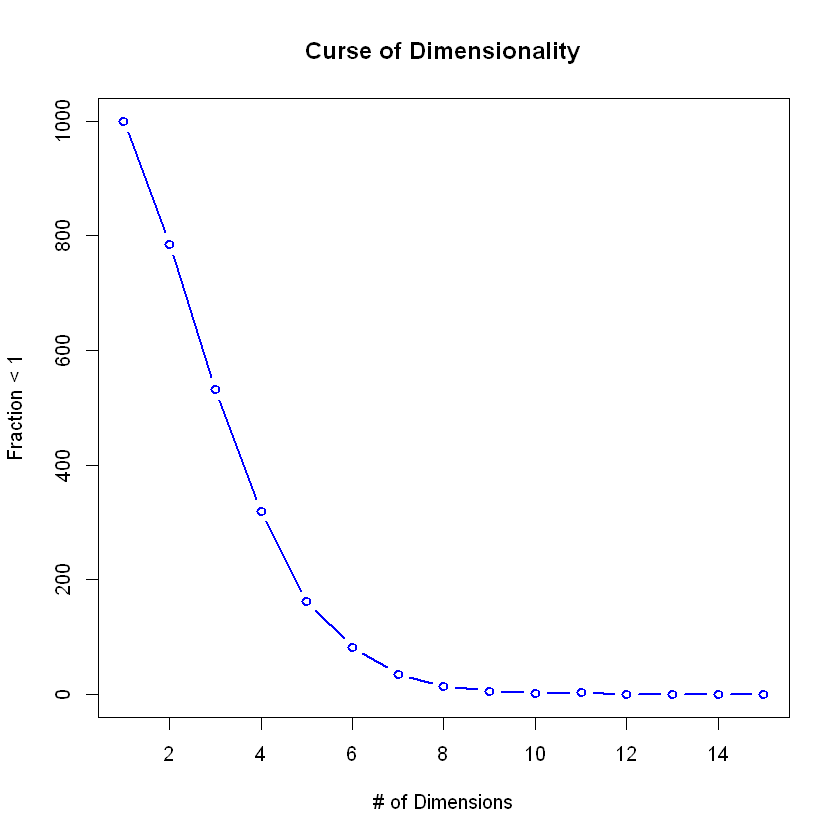

```r
set.seed(2021)

fraction_table <- function(D, number_of_points) {

    # create matrix that will store the data
    data <- matrix(runif(number_of_points * D, min=-1, max=1), nrow = number_of_points, ncol = D)
    origin <-  matrix(0, nrow = number_of_points, ncol = D)

    # calculate distance of each intances from the origin
    distances <- as.matrix(sqrt(rowSums((data - origin)^2)))

    # find the fraction of matrix less than 1
    fraction <- sum(distances < 1)

    # construct table
    data.frame(D, fraction)

}

result_table = lapply(D,
                      number_of_points,
                      FUN = fraction_table)

final_table <- do.call(rbind, result_table)

plot(final_table, type="b", col="blue", lwd=2, xlab="# of Dimensions", ylab="Fraction < 1", main="Curse of Dimensionality")
```

*b) Use the value of this fraction at D = 2 and D = 3 to get estimates for the value of pi (Π) as you know the area (for D = 2) and volume (for D = 3) formulae for these cases.*

###### For D=2

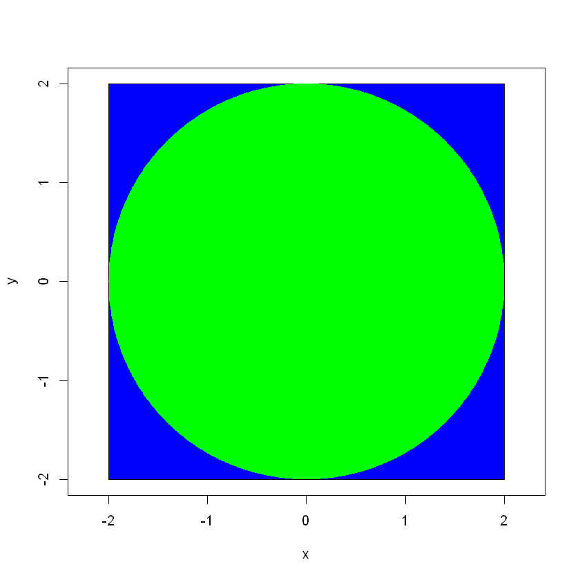

```r
plot(x, y, xlim = c(-2,2), ylim=c(-2,2), type='n', asp = 1)
x2 <- c(seq(-2, 2, 0.01), seq(-2, 2, 0.01))
y2 <- c((  1 * (4 - x2[1:401]^2)^0.5 ), ( -1 * (4 - x2[402:802]^2)^0.5 ))
rect(-2,-2,2,2, col = 'blue')
polygon(x2,y2, col = 'green', border = NA)
```

r <- 1

Area of circle = Πr^2

Area of square = 4r^2

(Probability of a point lie within distance 1 of the origin in D=2) = Πr^2/4r^2

(Probability of a point lie within distance 1 of the origin in D=2)*4 = Π

```r
final_table[D==1|D==2, ]
```

| D | fraction |
| --- | --- |
| 1 | 1000 |
| 2 | 786 |

```r
4*786/1000
```

3.144

This approximately equalsto Π

###### For D=3

r <- 1

Volume of sphere = 4/3Πr^3

Volume of cube = 8r^3

(Probability of a point lie within distance 1 of the origin in D=3) = 4/3Πr^3/8r^3

(Probability of a point lie within distance 1 of the origin in D=3)*6 = Π

```r
final_table[D==1|D==3, ]
```

|  | D | fraction |
| --- | --- | --- |
| 1 | 1 | 1000 |
| 3 | 3 | 533 |

```r
6*533/1000
```

3.198

This approximately equalsto Π

*c) Perform the calculations in part (b) with larger sample sizes. You can use the following set: {5000, 10000, 25000, 50000, 100000}. Visualize the estimated Π for D = 2 and D = 3 cases. Comment on your results*

```r
set.seed(2021)

datalist = list()
D <- 2:3

for (number_of_points in c(5000, 10000, 25000, 50000, 100000)) {

    result_data = lapply(D,
                        number_of_points,
                        FUN = fraction_table)

        final_table <- do.call(rbind, result_data)
        final_table$number_of_points <- number_of_points
        datalist[[number_of_points]] <- final_table
}

all_fractions = do.call(rbind, datalist)
```

```r
all_fractions
```

| D | fraction | number_of_points |
| --- | --- | --- |
| 2 | 3925 | 5000 |
| 3 | 2634 | 5000 |
| 2 | 7791 | 10000 |
| 3 | 5247 | 10000 |
| 2 | 19621 | 25000 |
| 3 | 13121 | 25000 |
| 2 | 39303 | 50000 |
| 3 | 26183 | 50000 |
| 2 | 78752 | 100000 |
| 3 | 52328 | 100000 |

```r
all_fractions$pi_estimation <- ifelse(all_fractions$D == 2,
                                      4*all_fractions$fraction/all_fractions$number_of_points,
                                      6*all_fractions$fraction/all_fractions$number_of_points)
```

###### For D=2

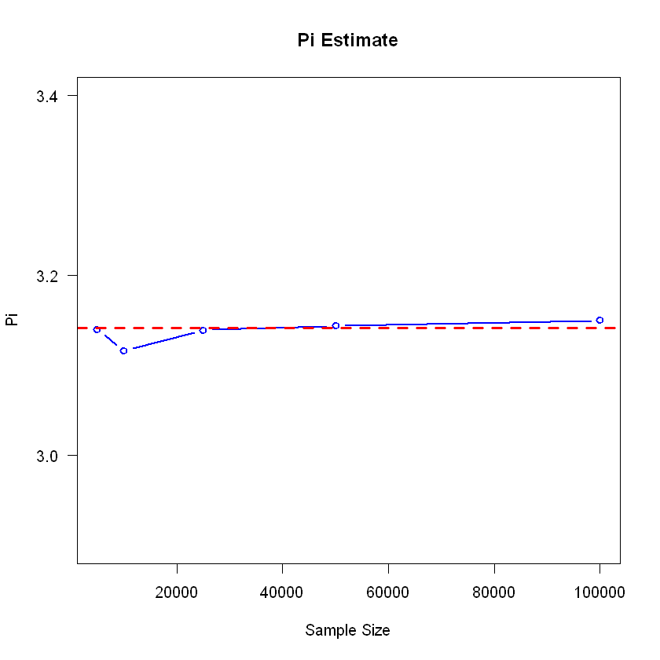

```r
plot(all_fractions[D==2,c("number_of_points", "pi_estimation")], type="b", col="blue",
     lwd=2, xlab="Sample Size", ylab="Pi", yaxt="n", ylim=c(2.9,3.4), main="Pi Estimate")
abline(h = pi, col="red", lwd=3, lty=2)
axis(2, at = seq(2, 4, by = 0.2), las=2)
```

###### For D=3

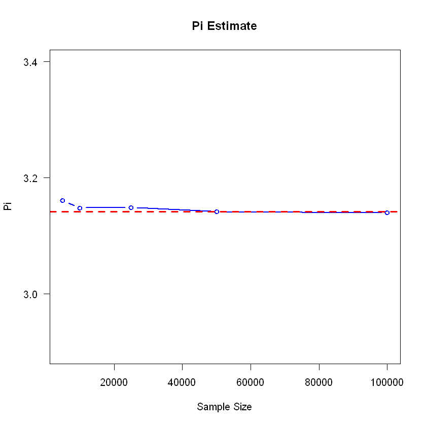

```r
plot(all_fractions[D==3,c("number_of_points", "pi_estimation")], type="b", col="blue",
     lwd=2, xlab="Sample Size", ylab="Pi", yaxt="n", ylim=c(2.9,3.4), main="Pi Estimate")
abline(h = pi, col="red", lwd=3, lty=2)
axis(2, at = seq(2, 4, by = 0.2), las=2)
```

*d) Repeat this simulation, sampling 1000 D-dimensional points from 1 to 15 dimensions, where the value in each dimension is uniformly randomly distributed between -1 and +1. For each value of D, generate an additional 100 test instances and calculate the distance to each test instance’s nearest neighbor. Plot the average distance from the test instances to their nearest neighbors as a function of D.*

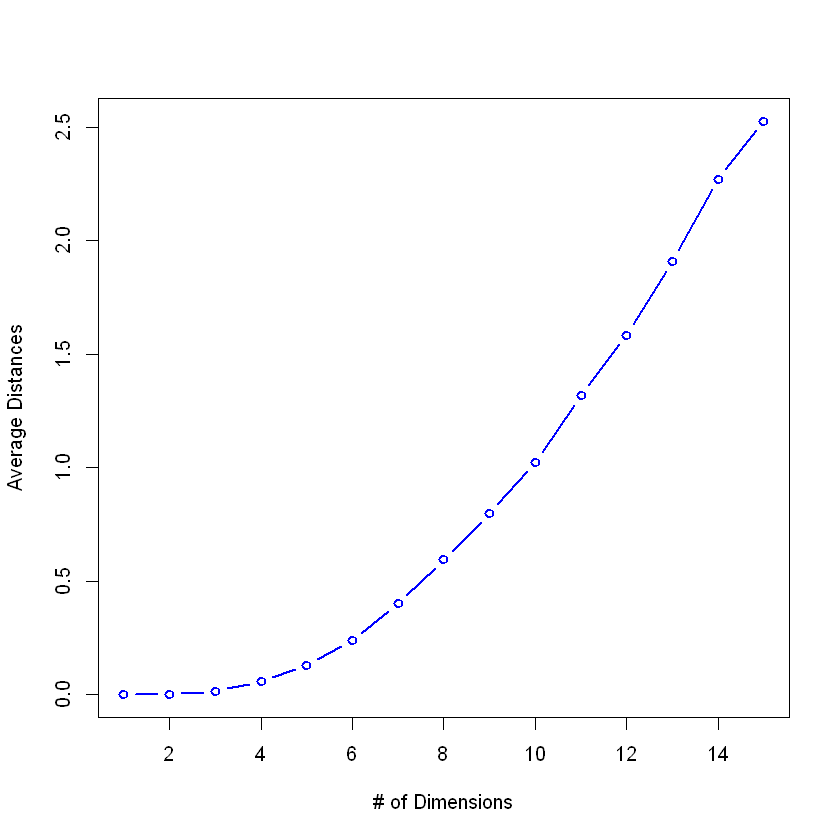

```r
number_of_test_instances <- 100

avg_distance_table <- function(D, number_of_points, number_of_test_instances) {

    # create matrix that will store the data
    # dimensions added as row so that apply function works properly
    data <- matrix(runif(number_of_points * D, min=-1, max=1), nrow = D, ncol = number_of_points)
    test_instances <-  matrix(runif(number_of_test_instances * D, min=-1, max=1), nrow = D, ncol = number_of_test_instances)

    # calculate the distance to each test instance’s
    distances <- apply(test_instances, 2, function(test_instance) {
         colSums((data - test_instance)^2)
    })

    # take column-wise min calculate the distance to each test instance’s nearest neighbor
    nearest_neighbor <- apply(distances, 2, FUN = min)

    # average distance from the test instances to their nearest neighbors
    avg_distances <- mean(nearest_neighbor)

    # construct table
    data.frame(D, avg_distances)

}

result_table = lapply(D,
                      number_of_points,
                      number_of_test_instances,
                      FUN = avg_distance_table)

final_table <- do.call(rbind, result_table)

plot(final_table, type="b", col="blue", lwd=2, xlab="# of Dimensions", ylab="Average Distances")
```

###### See sample calculations of the function:

```r
D = 2
number_of_points = 5
number_of_test_instances = 2

data <- matrix(runif(number_of_points * D, min=-1, max=1), nrow = D, ncol = number_of_points)
test_instances <-  matrix(runif(number_of_test_instances * D, min=-1, max=1), nrow = D, ncol = number_of_test_instances)
```

```r
# each column represents an instance
# (-0.04466295, -0.94327471), (0.9390605, 0.5575227)
data
```

| -0.04466295 | 0.9390605 | -0.3520766 | -0.831037 | -0.4696201 |
| --- | --- | --- | --- | --- |
| -0.94327471 | 0.5575227 | 0.3268797 | -0.596168 | -0.2748848 |

```r
test_instances
```

| 0.4770919 | -0.2874879 |
| --- | --- |
| 0.6790647 | -0.5719368 |

```r
distances <- apply(test_instances, 2, function(test_instance) {
             colSums((data - test_instance)^2)
    })
```

```r
# distance between (-0.04466295, -0.94327471) and first test instance (0.4770919, 0.6790647) = 2.9042133
# distance between (0.9390605, 0.5575227) and first test instance (0.4770919, 0.6790647) = 0.2281875
# distance between (-0.3520766, 0.3268797) and second test instance (-0.2874879, -0.5719368) = 0.8120427
distances
```

| 2.9042133 | 0.1968558 |
| --- | --- |
| 0.2281875 | 2.7800998 |
| 0.8115547 | 0.8120427 |
| 3.3374197 | 0.2960328 |
| 1.8062833 | 0.1214120 |

```r
nearest_neighbor <- apply(distances, 2, FUN = min)
```

```r
# first element shows min distance to first instance and second shows min distance to second instance
nearest_neighbor
```

1. 0.228187518851622

2. 0.121412017850196

```r
avg_distances <- mean(nearest_neighbor)
```

```r
# average of distance to nearest neigbour
# (0.228187518851622+0.121412017850196)/2
avg_distances
```

0.174799768350909

### Task 2 – Practicing data manipulation skills on images

Take a picture of yours and save it as *.jpg or* .jpeg file.

Using an image editor (i.e. Paint in Windows), crop your head from the image and save it as separate image file (again *.jpg or* .jpeg). The resulting image is expected to be a square (i.e. has the same length and width), hence you should crop the image accordingly.

Resize the cropped image to size 512x512 px (pixel) using an image editor. This image is the one that you will use for this exercise.

*a) Read image as a variable in R/Python. You need to install “jpeg” package to read image into a variable if you use R. For Python, an alternative is to use matplotlib package. What is the structure of the variable that stores the image? What is the dimension? a. Display the image. (Hint: google “rasterImage”)*

```r
install.packages("jpeg")
```

```
  There is a binary version available but the source version is later:
      binary source needs_compilation
jpeg 0.1-8.1  0.1-9              TRUE

  Binaries will be installed
```

```r
# assuming you have the photo in your working directory in the following format:
# 'working_directory/'
current_folder = getwd()
photo_name = "photo"
photo_path = sprintf('%s/%s.jpg', current_folder, photo_name)

require("jpeg")
photo <- readJPEG(photo_path, native = FALSE)
```

```r
str(photo)
```

```
 num [1:512, 1:512, 1:3] 0.882 0.882 0.886 0.886 0.886 ...
```

```r
dim(photo)
```

1. 512

2. 512

3. 3

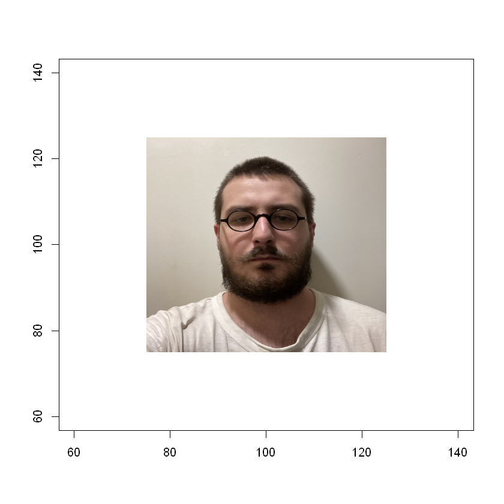

```r
plot(c(100, 100), c(100, 100), type = "n", xlab = "", ylab = "")
rasterImage(photo, xleft = 75, xright = 125, ybottom = 75, ytop = 125)
```

*b) Display each channel as separate image?*

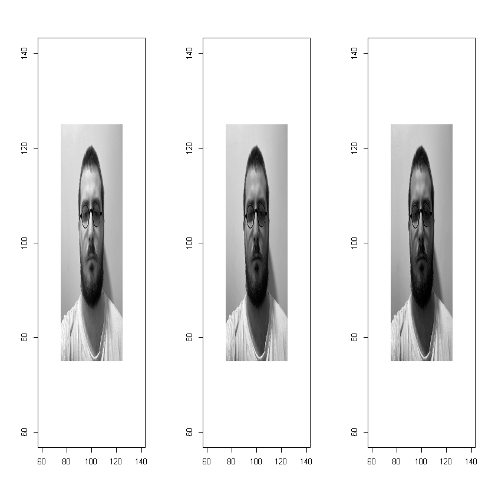

```r
par(mfrow=c(1,3))

for(i in c(1,2,3)){

    plot(c(100, 100), c(100, 100), type = "n", xlab = "", ylab = "")
    rasterImage(photo[,,i], xleft = 75, xright = 125, ybottom = 75, ytop = 125)

}
```

*c) For each channel, take the average of the columns and plot the average as a line plot for each channel on a single plot.*

```r
# create df that stores the information about column averages of channels
data <- data.frame(matrix(1:512, ncol = 1, nrow = 512))
colnames(data) <- c("index")

for(i in c(1,2,3)){

    ch <- as.data.frame(colMeans(photo[,,i]))
    colnames(ch) <- c(paste("ch",i, sep="_"))
    data <- cbind(data, ch)

}
```

[figure not shown]

```r
plot(data$index, data$ch_1, type="l", col="red", lwd=2, xlab="Index", ylab="Column Averages", ylim = c(0, 1))
lines(data$index, data$ch_2, col="green")
lines(data$index, data$ch_3, col="blue")
labels <- c("ch1", "ch2", "ch3")
legend("topright", legend=labels, cex=0.8, inset=0.05, col=c("red", "blue", "green"), lty=1)
```

*d) For each channel, subtract one half of the image from the other half (choice of halves is up to you but dividing the head image vertically into two parts make more sense). If you observe negative pixel values, you can make them equal to zero. Then:*

*• Display the new image.*

*• Display each channel separately as separate image.*

```r
photo_upd <- photo

for(i in c(1,2,3)){

    photo_upd[,1:256,i] <- photo_upd[,1:256,i]-photo_upd[,257:512,i]

}

photo_upd[photo_upd < 0] <- 0
```

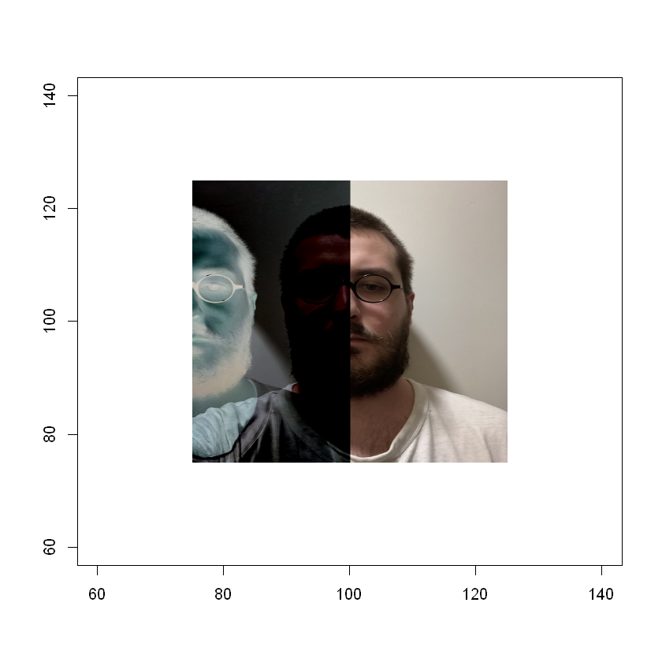

```r
plot(c(100, 100), c(100, 100), type = "n", xlab = "", ylab = "")
rasterImage(photo_upd, xleft = 75, xright = 125, ybottom = 75, ytop = 125)
```

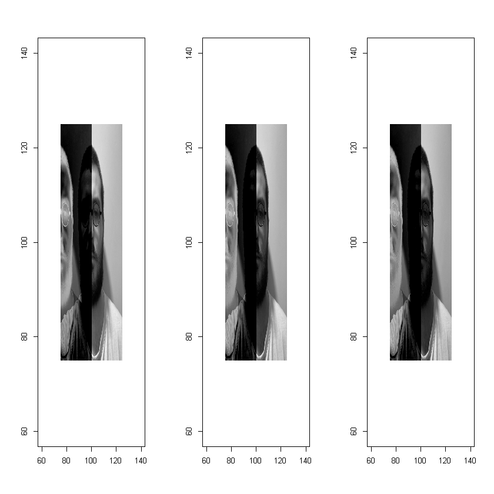

```r
par(mfrow=c(1,3))


for(i in c(1,2,3)){

    plot(c(100, 100), c(100, 100), type = "n", xlab = "", ylab = "")
    rasterImage(photo_upd[,,i], xleft = 75, xright = 125, ybottom = 75, ytop = 125)

}
```

*e) In order to create a noisy image, add a random noise from uniform distribution with minimum value of 0 and a maximum value of “0.1* maximum pixel value observed” to each pixel value for each channel of original image.*

*• Display the new image.*

*• Display each channel separately as separate image.*

```r
photo_noise <- photo


for(i in c(1,2,3)){

    noise <- matrix(runif(nrow(photo[,,i])* ncol(photo[,,i]), min=0, max=0.1*max(photo_noise[,,i])),
                nrow = nrow(photo[,,i]), ncol = ncol(photo[,,i]))

    photo_noise[,,i] <- photo_noise[,,i]+noise

}

photo_noise[photo_noise > 1] <- 1
```

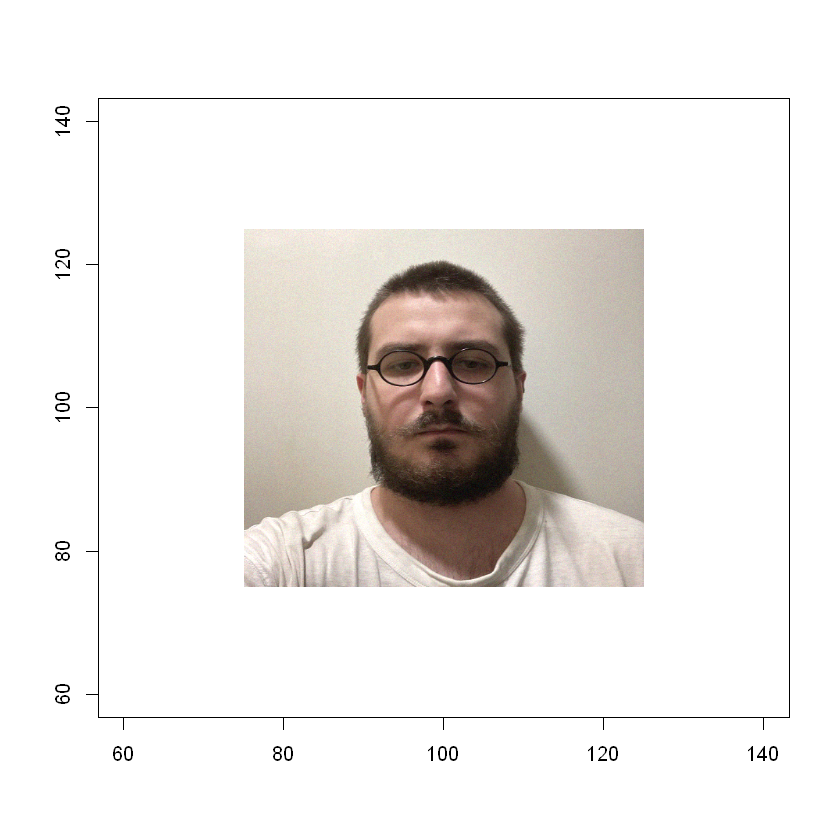

```r
plot(c(100, 100), c(100, 100), type = "n", xlab = "", ylab = "")
rasterImage(photo_noise, xleft = 75, xright = 125, ybottom = 75, ytop = 125)
```

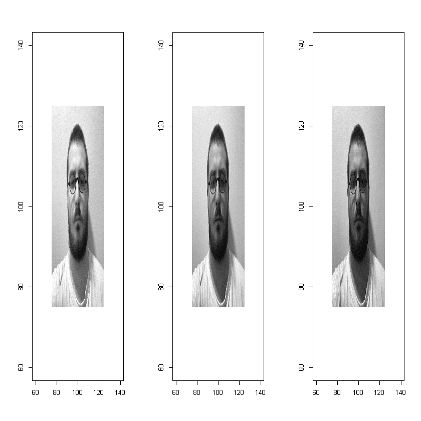

```r
par(mfrow=c(1,3))

for(i in c(1,2,3)){

    plot(c(100, 100), c(100, 100), type = "n", xlab = "", ylab = "")
    rasterImage(photo_noise[,,i], xleft = 75, xright = 125, ybottom = 75, ytop = 125)


}
```